# Psychometric Report On the questionnaire Kickstart Your Soft Skills based on the GOLEWEB database

# 1 Introduction

# 2 The KYSS-model

The theoretical framework on soft skills was developed during the KYSS-project [7]. In this project a literature review inventoried soft skills incorporated in existing soft skill-models. Subsequently, the top 25 of most frequently mentioned soft skills were prioritised by stakeholders in both the institute for higher education and the labour market. This resulted in a model of 16 soft skills organised in four overarching domains. These soft skills were deemed relevant for higher education and the workplace. *Figure 1* provides a schematic overview of the structure of the model, while *Table 1* contains a short description of the incorporated soft skills.

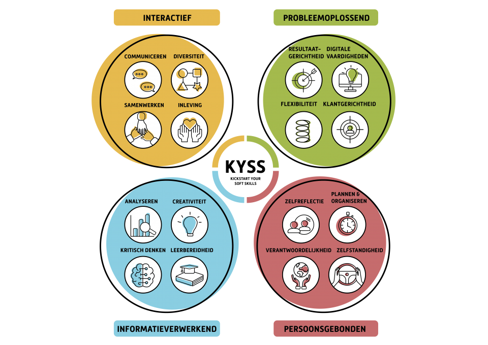

**Figure 1:** The KYSS model

Table 1: overview KYSS-scales

| Domain | Skill | Description |
| --- | --- | --- |
| Interaction | Communication | The way you communicate information orally and/or in writing. |
|  | Diversity | Your attitude towards people with a different background compared to yours and how you deal with them. |
|  | Cooperation | The way you behave and treat others while working together. |
|  | Empathy | The extent to which you pay attention to the feelings and needs of others, respect them and respond to them appropriately. |
| Problem solving | Result-oriented | The extent to which you think about the results you need to achieve and actively pursue your goals. |
|  | Digital skills | The extent to which you have the knowledge and skills to deal with ICT and technological developments. |
|  | Flexibility | The extent to which you adapt your approach or behaviour to changing circumstances. |
|  | Customer-oriented | The extent to which you take into account customers’ needs and act accordingly. |
| Information processing | Analysing | The extent to which you are able to analyse information, and connect various types or sources of information. |
|  | Creativity | The extent to which you develop original ideas, solutions or methods. |
|  | Critical Thinking | The extent to which you evaluate information in an objective and critical way in order to derive your own, well-founded conclusions. |
|  | Willingness to learn | The extent to which you are willing and able to expand your expertise through learning. |
| Personal | Self-reflection | The extent to which you reflect on your own behaviour and take account of feedback from others. |
|  | Planning & organising | The extent to which you set goals and priorities and manage your time efficiently. |
|  | Responsibility | The extent to which you follow rules, norms and values. |
|  | Independence | The extent to which you take initiative in performing tasks and are pro-active. |

# 3 Research questions

The following research questions are answered in the current psychometric report:

- **RQ1:** Do scales in the KYSS-questionnaire have sufficient construct validity?
- **RQ2:** Is the factor structure of the scales in the KYSS-questionnaire invariant across gender?
- **RQ3:** Is the factor structure of the scales in the KYSS-questionnaire invariant across Higher education institution?
- **RQ4:** Are the scales in the KYSS-questionnaire sufficiently reliable?
- **RQ5:** What are descripitive statistics for the scales in the KYSS-questionnaire?
- **RQ6:** How are the scales in the KYSS-questionnaire correlated?
- **RQ7:** Does gender predict scores on the scales in the KYSS-questionnaire?
- **RQ8:** Does Higer education institution predict scores on the scales in the KYSS-questionnaire?

# 4 Methodology

## 4.1 Sample

The sample for the current analysis consists of 2027 students who filled in the KYSS-questionnaire using the GOLEWEB digital surveying tool. These pertain to 5 institutions for higher education in Flanders. For informative purposes, frequency tables for the distribution of gender and higher education institutions are provided in *Table 2* and *Table 3* respectively.

Table 2: Frequency table for gender

| Gender | n | Percentage |
| --- | --- | --- |
| Female | 1,011 | 50 |
| Male | 1,016 | 50 |

Table 3: Frequency table for Institution

| Institution | n | Percentage |
| --- | --- | --- |
| AP Hogeschool | 330 | 16 |
| HOGENT | 299 | 15 |
| Hogeschool PXL - KYSS | 940 | 46 |
| Odisee | 43 | 2 |
| Thomas More | 415 | 20 |

Respondents pertain to various course-programmes within these institutions and also vary year they were currently enrolled in. All students filled in the KYSS-questionnaire during the academic year 2021-2022.

## 4.2 Data analysis approach

Analyses on **construct validity** were conducted using confirmatory factor analysis, using a maximum likelihood estimation with robust standard errors and a Satorra-Bentler scaled test statistic. In a first step, the validity of each separate scale was assessed, thereby using the *Comparative Fit Index (CFI)* and the *Root Mean Square Error of Approximation (RMSEA)* as primary fit statistics. Generally accepted cut-off points for good and acceptable model fit were applied (See *Table 3* for an overview)

Table 3: Cutoffs fit indices

| Fit_index | Acceptable_model_Fit | Good_model_Fit |
| --- | --- | --- |
| Comparative fit index | > .900 | > .950 |
| Root Mean Square Error of Approximation | <.080 | <.050 |

In the case of insufficient model fit, modification indices were analysed and used to enhance the model. To compare the models the *Bayesian Information Criterion (BIC)* and the *Akaike Information Criterion (AIC)* were used to compare the relative quality of the statistical models. For both criteria a beeter quality model is indicated by a lower value.

Analyses on **measurement invariance** were conducted using Multigroup Confirmatory Factor Analysis. Measurement invariance analyses tests as to whether or not a construct (Scale) is measured similarly across sub-groups in a sample (e.g. do males and females conceive the concept of creativity in a similar way?). This entails:

- 1. Looking at the overall quality of model fit when data is split into groups, as an indication that the same items load on the latent construct *(Configural Invariance)*
- 2. Investigating whether factor loadings are equal across groups, indicating that the same items have a similar ‘importance’ for various groups *(Weak Invariance)*
- 3. Exploring whether the intercepts of observed variables are equal across groups, indicating that various groups score items in a similar fashion *(Strong invariance)*

**Reliability** analyses were conducted by measuring Cronbach’s alpha measure for internal consistency. In line with conventions in social sciences a value of . 60 or higher is considered to indicate adequate reliability, while a value of at least .80 is considered as an indication of good quality.

Scales that exhibit adequate construct valadity, invariance and reliability will be incorporated in **substantive analyses**. For each scale descriptive statistics for ech scale will be provided, including, mean, median, standard deviation, mean absolute deviation, skewness and kurtosis. Aditionally, descriptive statistics will be visualised using box- and whiskerplots.

**Interrelations** between scales will be investigated using correlational analyses. The correlation coefficients will also be used as a measure of effect size, as indicated in *Table 4*

Table 4: Cutoffs strength correlations

| Level | Positive | Negative |
| --- | --- | --- |
| Weak correlation | >.20 | <-.20 |
| Moderate correlation | >.30 | <-.30 |
| Strong correlation | >.50 | <-.50 |

Finally **Substantive differences in scale scores across groups** will be explored using Analysis of Variance using respectively gender and institution as predictor and mean scale scores for eacht of the scales in the KYSS-questionnaire as dependents. As these aqnalyses are exploratory, no hypotheses off effect are formulated. In addition to sgnificance test partial Eta squared measures of effects size are computed. values of .01 or higher indicate a small effect, vallues of .08 or higher signify a moderate effect, while values of.14 or higher are an indication of a strong effect.

# 5 Results Psychometric Analyses per Scale

## 5.1 Communication

### 5.1.1 CFA

Model Fit Measures

| CFI | RMSEA | RMSEA.Lower | RMSEA.Upper | SRMR | AIC | BIC |
| --- | --- | --- | --- | --- | --- | --- |
| 0.975 | 0.04 | 0.03 | 0.052 | 0.024 | 31038.08 | 31115.88 |

### 5.1.2 Measurement invariance across Gender

```
##
## Measurement invariance models:
##
## Model 1 : fit.configural
## Model 2 : fit.loadings
## Model 3 : fit.intercepts
## Model 4 : fit.means
##
## Scaled Chi-Squared Difference Test (method = "satorra.bentler.2001")
##
## lavaan NOTE:
##     The "Chisq" column contains standard test statistics, not the
##     robust test that should be reported per model. A robust difference
##     test is a function of two standard (not robust) statistics.
##
##                Df   AIC   BIC   Chisq Chisq diff Df diff Pr(>Chisq)
## fit.configural 28 31024 31258  75.228
## fit.loadings   34 31019 31219  81.328      5.171       6    0.52213
## fit.intercepts 40 31049 31216 123.979     44.964       6  4.759e-08 ***
## fit.means      41 31050 31211 126.915      2.952       1    0.08576 .
## ---
## Signif. codes:  0 '***' 0.001 '**' 0.01 '*' 0.05 '.' 0.1 ' ' 1
##
##
## Fit measures:
##
##                cfi.robust rmsea.robust cfi.robust.delta rmsea.robust.delta
## fit.configural      0.977        0.039               NA                 NA
## fit.loadings        0.977        0.035            0.001              0.004
## fit.intercepts      0.956        0.045            0.021              0.010
## fit.means           0.955        0.045            0.001              0.000
```

### 5.1.4 Reliability

| raw_alpha | std.alpha | G6(smc) | average_r | S/N | ase | mean | sd | median_r |
| --- | --- | --- | --- | --- | --- | --- | --- | --- |
| 0.64 | 0.68 | 0.66 | 0.23 | 2.09 | 0.01 | 3.71 | 0.48 | 0.26 |

## 5.2 Diversity

### 5.2.1 CFA

Model Fit Measures

| CFI | RMSEA | RMSEA.Lower | RMSEA.Upper | SRMR | AIC | BIC |
| --- | --- | --- | --- | --- | --- | --- |
| 0.949 | 0.093 | 0.079 | 0.107 | 0.04 | 17487.91 | 17551.73 |

Fit measures demonstrate inadequate model fit. Modification indices pointed out that allowing covariance between items K_Divers02 and K_Divers04 would improve model fit.

Model Fit Measures

| CFI | RMSEA | RMSEA.Lower | RMSEA.Upper | SRMR | AIC | BIC |
| --- | --- | --- | --- | --- | --- | --- |
| 0.977 | 0.066 | 0.051 | 0.082 | 0.028 | 17425.15 | 17494.28 |

Fit measures demonstrate that allowing covariance resulted in adequate model-fit. Analyses also pointed that the second model is significantly better than the first.

| Df | AIC | BIC | Chisq | Chisq diff | Df diff | Pr(>Chisq) |
| --- | --- | --- | --- | --- | --- | --- |
| 8 | 17,425.15 | 17,494.28 | 60.47601 |  |  |  |
| 9 | 17,487.91 | 17,551.73 | 125.24080 | 45.1264 | 1 | 0.00000000001847182 |

### 5.2.2 Measurement invariance across Gender

```
##
## Measurement invariance models:
##
## Model 1 : fit.configural
## Model 2 : fit.loadings
## Model 3 : fit.intercepts
## Model 4 : fit.means
##
## Scaled Chi-Squared Difference Test (method = "satorra.bentler.2001")
##
## lavaan NOTE:
##     The "Chisq" column contains standard test statistics, not the
##     robust test that should be reported per model. A robust difference
##     test is a function of two standard (not robust) statistics.
##
##                Df   AIC   BIC   Chisq Chisq diff Df diff Pr(>Chisq)
## fit.configural 16 17352 17554  69.203
## fit.loadings   21 17348 17524  75.533      5.508       5   0.357027
## fit.intercepts 26 17356 17505  93.538     18.129       5   0.002789 **
## fit.means      27 17391 17534 129.830     46.779       1  7.947e-12 ***
## ---
## Signif. codes:  0 '***' 0.001 '**' 0.01 '*' 0.05 '.' 0.1 ' ' 1
##
##
## Fit measures:
##
##                cfi.robust rmsea.robust cfi.robust.delta rmsea.robust.delta
## fit.configural      0.978        0.064               NA                 NA
## fit.loadings        0.978        0.056            0.000              0.008
## fit.intercepts      0.972        0.057            0.006              0.001
## fit.means           0.956        0.069            0.016              0.013
```

### 5.2.3 Measurement invariance across Institutions

```
##
## Measurement invariance models:
##
## Model 1 : fit.configural
## Model 2 : fit.loadings
## Model 3 : fit.intercepts
## Model 4 : fit.means
##
## Scaled Chi-Squared Difference Test (method = "satorra.bentler.2001")
##
## lavaan NOTE:
##     The "Chisq" column contains standard test statistics, not the
##     robust test that should be reported per model. A robust difference
##     test is a function of two standard (not robust) statistics.
##
##                Df   AIC   BIC   Chisq Chisq diff Df diff Pr(>Chisq)
## fit.configural 40 17412 17918  92.938
## fit.loadings   60 17390 17789 110.483     14.969      20     0.7782
## fit.intercepts 80 17398 17691 158.704     59.695      20  7.939e-06 ***
## fit.means      84 17415 17686 183.772     36.127       4  2.724e-07 ***
## ---
## Signif. codes:  0 '***' 0.001 '**' 0.01 '*' 0.05 '.' 0.1 ' ' 1
##
##
## Fit measures:
##
##                cfi.robust rmsea.robust cfi.robust.delta rmsea.robust.delta
## fit.configural      0.981        0.059               NA                 NA
## fit.loadings        0.984        0.045            0.003              0.014
## fit.intercepts      0.970        0.053            0.014              0.008
## fit.means           0.960        0.060            0.010              0.007
```

### 5.2.4 Reliability

| raw_alpha | std.alpha | G6(smc) | average_r | S/N | ase | mean | sd | median_r |
| --- | --- | --- | --- | --- | --- | --- | --- | --- |
| 0.78 | 0.79 | 0.77 | 0.39 | 3.77 | 0.01 | 4.28 | 0.51 | 0.38 |

## 5.3 Cooperation

### 5.3.1 CFA

Model Fit Measures

| CFI | RMSEA | RMSEA.Lower | RMSEA.Upper | SRMR | AIC | BIC |
| --- | --- | --- | --- | --- | --- | --- |
| 0.963 | 0.058 | 0.046 | 0.071 | 0.029 | 26627.96 | 26695.08 |

### 5.3.2 Measurement invariance across Gender

```
##
## Measurement invariance models:
##
## Model 1 : fit.configural
## Model 2 : fit.loadings
## Model 3 : fit.intercepts
## Model 4 : fit.means
##
## Scaled Chi-Squared Difference Test (method = "satorra.bentler.2001")
##
## lavaan NOTE:
##     The "Chisq" column contains standard test statistics, not the
##     robust test that should be reported per model. A robust difference
##     test is a function of two standard (not robust) statistics.
##
##                Df   AIC   BIC   Chisq Chisq diff Df diff Pr(>Chisq)
## fit.configural 18 26600 26801  81.169
## fit.loadings   23 26595 26769  86.266      4.652       5     0.4598
## fit.intercepts 28 26629 26775 130.464     46.525       5  7.101e-09 ***
## fit.means      29 26627 26767 130.550      0.085       1     0.7702
## ---
## Signif. codes:  0 '***' 0.001 '**' 0.01 '*' 0.05 '.' 0.1 ' ' 1
##
##
## Fit measures:
##
##                cfi.robust rmsea.robust cfi.robust.delta rmsea.robust.delta
## fit.configural      0.964        0.058               NA                 NA
## fit.loadings        0.964        0.051            0.000              0.007
## fit.intercepts      0.940        0.059            0.024              0.009
## fit.means           0.940        0.058            0.001              0.001
```

### 5.3.3 Measurement invariance across Institutions

```
##
## Measurement invariance models:
##
## Model 1 : fit.configural
## Model 2 : fit.loadings
## Model 3 : fit.intercepts
## Model 4 : fit.means
##
## Scaled Chi-Squared Difference Test (method = "satorra.bentler.2001")
##
## lavaan NOTE:
##     The "Chisq" column contains standard test statistics, not the
##     robust test that should be reported per model. A robust difference
##     test is a function of two standard (not robust) statistics.
##
##                Df   AIC   BIC  Chisq Chisq diff Df diff Pr(>Chisq)
## fit.configural 45 26607 27111 104.38
## fit.loadings   65 26596 26988 133.01     28.533      20    0.09736 .
## fit.intercepts 85 26632 26912 208.99     86.207      20  3.387e-10 ***
## fit.means      89 26649 26906 233.56     28.965       4  7.945e-06 ***
## ---
## Signif. codes:  0 '***' 0.001 '**' 0.01 '*' 0.05 '.' 0.1 ' ' 1
##
##
## Fit measures:
##
##                cfi.robust rmsea.robust cfi.robust.delta rmsea.robust.delta
## fit.configural      0.969        0.053               NA                 NA
## fit.loadings        0.963        0.048            0.005              0.005
## fit.intercepts      0.927        0.059            0.037              0.011
## fit.means           0.913        0.062            0.013              0.004
```

### 5.3.4 Reliability

| raw_alpha | std.alpha | G6(smc) | average_r | S/N | ase | mean | sd | median_r |
| --- | --- | --- | --- | --- | --- | --- | --- | --- |
| 0.69 | 0.69 | 0.66 | 0.27 | 2.21 | 0.01 | 3.88 | 0.50 | 0.30 |

## 5.4 Empathy

### 5.4.1 CFA

Model Fit Measures

| CFI | RMSEA | RMSEA.Lower | RMSEA.Upper | SRMR | AIC | BIC |
| --- | --- | --- | --- | --- | --- | --- |
| 0.961 | 0.078 | 0.064 | 0.093 | 0.039 | 18718.66 | 18782.94 |

### 5.4.2 Measurement invariance across Gender

```
##
## Measurement invariance models:
##
## Model 1 : fit.configural
## Model 2 : fit.loadings
## Model 3 : fit.intercepts
## Model 4 : fit.means
##
## Scaled Chi-Squared Difference Test (method = "satorra.bentler.2001")
##
## lavaan NOTE:
##     The "Chisq" column contains standard test statistics, not the
##     robust test that should be reported per model. A robust difference
##     test is a function of two standard (not robust) statistics.
##
##                Df   AIC   BIC   Chisq Chisq diff Df diff Pr(>Chisq)
## fit.configural 18 18442 18635  99.549
## fit.loadings   23 18444 18610 111.468       9.86       5  0.0792389 .
## fit.intercepts 28 18457 18596 135.047      24.00       5  0.0002174 ***
## fit.means      29 18602 18736 282.212     480.53       1  < 2.2e-16 ***
## ---
## Signif. codes:  0 '***' 0.001 '**' 0.01 '*' 0.05 '.' 0.1 ' ' 1
##
##
## Fit measures:
##
##                cfi.robust rmsea.robust cfi.robust.delta rmsea.robust.delta
## fit.configural      0.960        0.075               NA                 NA
## fit.loadings        0.957        0.068            0.003              0.006
## fit.intercepts      0.948        0.069            0.010              0.000
## fit.means           0.873        0.105            0.075              0.036
```

### 5.4.3 Measurement invariance across Institutions

```
##
## Measurement invariance models:
##
## Model 1 : fit.configural
## Model 2 : fit.loadings
## Model 3 : fit.intercepts
## Model 4 : fit.means
##
## Scaled Chi-Squared Difference Test (method = "satorra.bentler.2001")
##
## lavaan NOTE:
##     The "Chisq" column contains standard test statistics, not the
##     robust test that should be reported per model. A robust difference
##     test is a function of two standard (not robust) statistics.
##
##                Df   AIC   BIC  Chisq Chisq diff Df diff Pr(>Chisq)
## fit.configural 45 18669 19151 148.22
## fit.loadings   65 18680 19054 199.15     39.999      20   0.004997 **
## fit.intercepts 85 18670 18938 229.71     32.453      20   0.038703 *
## fit.means      89 18707 18953 274.63     77.887       4   4.88e-16 ***
## ---
## Signif. codes:  0 '***' 0.001 '**' 0.01 '*' 0.05 '.' 0.1 ' ' 1
##
##
## Fit measures:
##
##                cfi.robust rmsea.robust cfi.robust.delta rmsea.robust.delta
## fit.configural      0.954        0.084               NA                 NA
## fit.loadings        0.943        0.078            0.012              0.006
## fit.intercepts      0.937        0.072            0.005              0.007
## fit.means           0.918        0.080            0.020              0.009
```

### 5.4.4 Reliability

| raw_alpha | std.alpha | G6(smc) | average_r | S/N | ase | mean | sd | median_r |
| --- | --- | --- | --- | --- | --- | --- | --- | --- |
| 0.73 | 0.74 | 0.73 | 0.32 | 2.84 | 0.01 | 4.06 | 0.56 | 0.35 |

## 5.5 Result oriented working

### 5.5.1 CFA

Model Fit Measures

| CFI | RMSEA | RMSEA.Lower | RMSEA.Upper | SRMR | AIC | BIC |
| --- | --- | --- | --- | --- | --- | --- |
| 0.97 | 0.053 | 0.043 | 0.064 | 0.027 | 27879.54 | 27957.31 |

### 5.5.2 Measurement invariance across Gender

```
##
## Measurement invariance models:
##
## Model 1 : fit.configural
## Model 2 : fit.loadings
## Model 3 : fit.intercepts
## Model 4 : fit.means
##
## Scaled Chi-Squared Difference Test (method = "satorra.bentler.2001")
##
## lavaan NOTE:
##     The "Chisq" column contains standard test statistics, not the
##     robust test that should be reported per model. A robust difference
##     test is a function of two standard (not robust) statistics.
##
##                Df   AIC   BIC  Chisq Chisq diff Df diff Pr(>Chisq)
## fit.configural 28 27873 28106 124.26
## fit.loadings   34 27875 28075 137.91     12.609       6    0.04968 *
## fit.intercepts 40 27900 28067 175.49     39.392       6  5.996e-07 ***
## fit.means      41 27898 28060 175.60      0.111       1    0.73903
## ---
## Signif. codes:  0 '***' 0.001 '**' 0.01 '*' 0.05 '.' 0.1 ' ' 1
##
##
## Fit measures:
##
##                cfi.robust rmsea.robust cfi.robust.delta rmsea.robust.delta
## fit.configural      0.965        0.058               NA                 NA
## fit.loadings        0.962        0.054            0.003              0.003
## fit.intercepts      0.949        0.058            0.013              0.003
## fit.means           0.950        0.057            0.000              0.001
```

### 5.5.3 Measurement invariance across Institutions

```
##
## Measurement invariance models:
##
## Model 1 : fit.configural
## Model 2 : fit.loadings
## Model 3 : fit.intercepts
## Model 4 : fit.means
##
## Scaled Chi-Squared Difference Test (method = "satorra.bentler.2001")
##
## lavaan NOTE:
##     The "Chisq" column contains standard test statistics, not the
##     robust test that should be reported per model. A robust difference
##     test is a function of two standard (not robust) statistics.
##
##                 Df   AIC   BIC  Chisq Chisq diff Df diff Pr(>Chisq)
## fit.configural  70 27821 28405 193.92
## fit.loadings    94 27803 28253 223.62     26.294      24     0.3384
## fit.intercepts 118 27849 28165 317.22    111.989      24  2.530e-13 ***
## fit.means      122 27864 28159 340.93     26.111       4  3.005e-05 ***
## ---
## Signif. codes:  0 '***' 0.001 '**' 0.01 '*' 0.05 '.' 0.1 ' ' 1
##
##
## Fit measures:
##
##                cfi.robust rmsea.robust cfi.robust.delta rmsea.robust.delta
## fit.configural      0.958        0.064               NA                 NA
## fit.loadings        0.957        0.056            0.001              0.008
## fit.intercepts      0.928        0.064            0.029              0.008
## fit.means           0.920        0.066            0.008              0.002
```

### 5.5.4 Reliability

| raw_alpha | std.alpha | G6(smc) | average_r | S/N | ase | mean | sd | median_r |
| --- | --- | --- | --- | --- | --- | --- | --- | --- |
| 0.76 | 0.76 | 0.74 | 0.32 | 3.26 | 0.01 | 3.78 | 0.49 | 0.32 |

## 5.6 Digital Skills

### 5.6.1 CFA

Model Fit Measures

| CFI | RMSEA | RMSEA.Lower | RMSEA.Upper | SRMR | AIC | BIC |
| --- | --- | --- | --- | --- | --- | --- |
| 1 | 0 | 0 | 0.047 | 0.007 | 17273.33 | 17316.71 |

### 5.6.2 Measurement invariance across Gender

```
##
## Measurement invariance models:
##
## Model 1 : fit.configural
## Model 2 : fit.loadings
## Model 3 : fit.intercepts
## Model 4 : fit.means
##
## Scaled Chi-Squared Difference Test (method = "satorra.bentler.2001")
##
## lavaan NOTE:
##     The "Chisq" column contains standard test statistics, not the
##     robust test that should be reported per model. A robust difference
##     test is a function of two standard (not robust) statistics.
##
##                Df   AIC   BIC    Chisq Chisq diff Df diff Pr(>Chisq)
## fit.configural  4 17076 17206   3.3977
## fit.loadings    7 17093 17206  26.3280     20.912       3  0.0001098 ***
## fit.intercepts 10 17165 17263 105.2307     80.376       3  < 2.2e-16 ***
## fit.means      11 17288 17381 230.1621    215.800       1  < 2.2e-16 ***
## ---
## Signif. codes:  0 '***' 0.001 '**' 0.01 '*' 0.05 '.' 0.1 ' ' 1
##
##
## Fit measures:
##
##                cfi.robust rmsea.robust cfi.robust.delta rmsea.robust.delta
## fit.configural      1.000        0.000               NA                 NA
## fit.loadings        0.984        0.057            0.016              0.057
## fit.intercepts      0.918        0.106            0.066              0.050
## fit.means           0.809        0.154            0.108              0.048
```

### 5.6.3 Measurement invariance across Institutions

```
##
## Measurement invariance models:
##
## Model 1 : fit.configural
## Model 2 : fit.loadings
## Model 3 : fit.intercepts
## Model 4 : fit.means
##
## Scaled Chi-Squared Difference Test (method = "satorra.bentler.2001")
##
## lavaan NOTE:
##     The "Chisq" column contains standard test statistics, not the
##     robust test that should be reported per model. A robust difference
##     test is a function of two standard (not robust) statistics.
##
##                Df   AIC   BIC   Chisq Chisq diff Df diff Pr(>Chisq)
## fit.configural 10 17051 17376  17.651
## fit.loadings   22 17054 17314  44.995     26.651      12   0.008673 **
## fit.intercepts 34 17149 17344 163.704    157.243      12  < 2.2e-16 ***
## fit.means      38 17229 17402 251.754    117.556       4  < 2.2e-16 ***
## ---
## Signif. codes:  0 '***' 0.001 '**' 0.01 '*' 0.05 '.' 0.1 ' ' 1
##
##
## Fit measures:
##
##                cfi.robust rmsea.robust cfi.robust.delta rmsea.robust.delta
## fit.configural      0.995        0.041               NA                 NA
## fit.loadings        0.983        0.053            0.013              0.012
## fit.intercepts      0.890        0.107            0.093              0.054
## fit.means           0.818        0.130            0.072              0.023
```

### 5.6.4 Reliability

| raw_alpha | std.alpha | G6(smc) | average_r | S/N | ase | mean | sd | median_r |
| --- | --- | --- | --- | --- | --- | --- | --- | --- |
| 0.70 | 0.70 | 0.65 | 0.37 | 2.33 | 0.01 | 3.57 | 0.71 | 0.36 |

## 5.7 Flexibility

### 5.7.1 CFA

Model Fit Measures

| CFI | RMSEA | RMSEA.Lower | RMSEA.Upper | SRMR | AIC | BIC |
| --- | --- | --- | --- | --- | --- | --- |
| 0.962 | 0.068 | 0.056 | 0.081 | 0.036 | 25744.22 | 25811.43 |

### 5.7.2 Measurement invariance across Gender

```
##
## Measurement invariance models:
##
## Model 1 : fit.configural
## Model 2 : fit.loadings
## Model 3 : fit.intercepts
## Model 4 : fit.means
##
## Scaled Chi-Squared Difference Test (method = "satorra.bentler.2001")
##
## lavaan NOTE:
##     The "Chisq" column contains standard test statistics, not the
##     robust test that should be reported per model. A robust difference
##     test is a function of two standard (not robust) statistics.
##
##                Df   AIC   BIC   Chisq Chisq diff Df diff Pr(>Chisq)
## fit.configural 18 25691 25892  94.144
## fit.loadings   23 25691 25864 104.149      8.141       5     0.1486
## fit.intercepts 28 25750 25895 173.423     75.569       5  7.079e-15 ***
## fit.means      29 25748 25888 173.588      0.163       1     0.6862
## ---
## Signif. codes:  0 '***' 0.001 '**' 0.01 '*' 0.05 '.' 0.1 ' ' 1
##
##
## Fit measures:
##
##                cfi.robust rmsea.robust cfi.robust.delta rmsea.robust.delta
## fit.configural      0.968        0.063               NA                 NA
## fit.loadings        0.966        0.057            0.002              0.006
## fit.intercepts      0.936        0.071            0.030              0.014
## fit.means           0.937        0.069            0.000              0.001
```

### 5.7.3 Measurement invariance across Institutions

```
##
## Measurement invariance models:
##
## Model 1 : fit.configural
## Model 2 : fit.loadings
## Model 3 : fit.intercepts
## Model 4 : fit.means
##
## Scaled Chi-Squared Difference Test (method = "satorra.bentler.2001")
##
## lavaan NOTE:
##     The "Chisq" column contains standard test statistics, not the
##     robust test that should be reported per model. A robust difference
##     test is a function of two standard (not robust) statistics.
##
##                Df   AIC   BIC  Chisq Chisq diff Df diff Pr(>Chisq)
## fit.configural 45 25691 26195 137.41
## fit.loadings   65 25675 26067 161.22     19.926      20     0.4626
## fit.intercepts 85 25712 25992 238.26     82.210      20  1.650e-09 ***
## fit.means      89 25747 26005 281.35     50.737       4  2.534e-10 ***
## ---
## Signif. codes:  0 '***' 0.001 '**' 0.01 '*' 0.05 '.' 0.1 ' ' 1
##
##
## Fit measures:
##
##                cfi.robust rmsea.robust cfi.robust.delta rmsea.robust.delta
## fit.configural      0.961        0.068               NA                 NA
## fit.loadings        0.961        0.056            0.000              0.011
## fit.intercepts      0.934        0.064            0.027              0.008
## fit.means           0.915        0.071            0.019              0.007
```

### 5.7.4 Reliability

| raw_alpha | std.alpha | G6(smc) | average_r | S/N | ase | mean | sd | median_r |
| --- | --- | --- | --- | --- | --- | --- | --- | --- |
| 0.73 | 0.73 | 0.71 | 0.31 | 2.68 | 0.01 | 3.91 | 0.52 | 0.31 |

## 5.8 Customer orientation

### 5.8.1 CFA

Model Fit Measures

| CFI | RMSEA | RMSEA.Lower | RMSEA.Upper | SRMR | AIC | BIC |
| --- | --- | --- | --- | --- | --- | --- |
| 0.982 | 0.05 | 0.035 | 0.066 | 0.023 | 15262.71 | 15325.94 |

### 5.8.2 Measurement invariance across Gender

```
##
## Measurement invariance models:
##
## Model 1 : fit.configural
## Model 2 : fit.loadings
## Model 3 : fit.intercepts
## Model 4 : fit.means
##
## Scaled Chi-Squared Difference Test (method = "satorra.bentler.2001")
##
## lavaan NOTE:
##     The "Chisq" column contains standard test statistics, not the
##     robust test that should be reported per model. A robust difference
##     test is a function of two standard (not robust) statistics.
##
##                Df   AIC   BIC   Chisq Chisq diff Df diff Pr(>Chisq)
## fit.configural 18 15196 15385  44.455
## fit.loadings   23 15200 15363  58.522     13.423       5    0.01972 *
## fit.intercepts 28 15269 15406 138.431     91.245       5    < 2e-16 ***
## fit.means      29 15270 15402 140.871      2.442       1    0.11812
## ---
## Signif. codes:  0 '***' 0.001 '**' 0.01 '*' 0.05 '.' 0.1 ' ' 1
##
##
## Fit measures:
##
##                cfi.robust rmsea.robust cfi.robust.delta rmsea.robust.delta
## fit.configural      0.988        0.041               NA                 NA
## fit.loadings        0.983        0.043            0.005              0.002
## fit.intercepts      0.941        0.073            0.042              0.030
## fit.means           0.941        0.072            0.001              0.001
```

### 5.8.3 Measurement invariance across Institutions

```
##
## Measurement invariance models:
##
## Model 1 : fit.configural
## Model 2 : fit.loadings
## Model 3 : fit.intercepts
## Model 4 : fit.means
##
## Scaled Chi-Squared Difference Test (method = "satorra.bentler.2001")
##
## lavaan NOTE:
##     The "Chisq" column contains standard test statistics, not the
##     robust test that should be reported per model. A robust difference
##     test is a function of two standard (not robust) statistics.
##
##                Df   AIC   BIC   Chisq Chisq diff Df diff Pr(>Chisq)
## fit.configural 45 15260 15734  78.929
## fit.loadings   65 15234 15602  92.746     10.971      20   0.946971
## fit.intercepts 85 15270 15534 169.416     96.832      20  4.626e-12 ***
## fit.means      89 15274 15516 180.829     15.963       4   0.003069 **
## ---
## Signif. codes:  0 '***' 0.001 '**' 0.01 '*' 0.05 '.' 0.1 ' ' 1
##
##
## Fit measures:
##
##                cfi.robust rmsea.robust cfi.robust.delta rmsea.robust.delta
## fit.configural      0.987        0.042               NA                 NA
## fit.loadings        0.994        0.025            0.006              0.017
## fit.intercepts      0.960        0.054            0.034              0.030
## fit.means           0.955        0.056            0.005              0.002
```

### 5.8.4 Reliability

| raw_alpha | std.alpha | G6(smc) | average_r | S/N | ase | mean | sd | median_r |
| --- | --- | --- | --- | --- | --- | --- | --- | --- |
| 0.76 | 0.76 | 0.74 | 0.35 | 3.23 | 0.01 | 4.19 | 0.50 | 0.38 |

## 5.9 Analysing

### 5.9.1 CFA

Model Fit Measures

| CFI | RMSEA | RMSEA.Lower | RMSEA.Upper | SRMR | AIC | BIC |
| --- | --- | --- | --- | --- | --- | --- |
| 0.996 | 0.022 | 0 | 0.044 | 0.014 | 19805.83 | 19860.99 |

### 5.9.2 Measurement invariance across Gender

```
##
## Measurement invariance models:
##
## Model 1 : fit.configural
## Model 2 : fit.loadings
## Model 3 : fit.intercepts
## Model 4 : fit.means
##
## Scaled Chi-Squared Difference Test (method = "satorra.bentler.2001")
##
## lavaan NOTE:
##     The "Chisq" column contains standard test statistics, not the
##     robust test that should be reported per model. A robust difference
##     test is a function of two standard (not robust) statistics.
##
##                Df   AIC   BIC  Chisq Chisq diff Df diff Pr(>Chisq)
## fit.configural 10 19800 19966 22.577
## fit.loadings   14 19797 19941 27.715     4.5104       4   0.341317
## fit.intercepts 18 19805 19926 43.500    16.1219       4   0.002860 **
## fit.means      19 19812 19928 52.309     8.9674       1   0.002748 **
## ---
## Signif. codes:  0 '***' 0.001 '**' 0.01 '*' 0.05 '.' 0.1 ' ' 1
##
##
## Fit measures:
##
##                cfi.robust rmsea.robust cfi.robust.delta rmsea.robust.delta
## fit.configural      0.991        0.033               NA                 NA
## fit.loadings        0.991        0.029            0.001              0.004
## fit.intercepts      0.980        0.037            0.010              0.008
## fit.means           0.974        0.042            0.007              0.005
```

### 5.9.3 Measurement invariance across Institutions

```
##
## Measurement invariance models:
##
## Model 1 : fit.configural
## Model 2 : fit.loadings
## Model 3 : fit.intercepts
## Model 4 : fit.means
##
## Scaled Chi-Squared Difference Test (method = "satorra.bentler.2001")
##
## lavaan NOTE:
##     The "Chisq" column contains standard test statistics, not the
##     robust test that should be reported per model. A robust difference
##     test is a function of two standard (not robust) statistics.
##
##                Df   AIC   BIC   Chisq Chisq diff Df diff Pr(>Chisq)
## fit.configural 25 19718 20131  43.057
## fit.loadings   41 19730 20056  87.749     39.332      16  0.0009737 ***
## fit.intercepts 57 19781 20018 170.565     96.348      16  1.668e-13 ***
## fit.means      61 19796 20011 193.279     24.368       4  6.739e-05 ***
## ---
## Signif. codes:  0 '***' 0.001 '**' 0.01 '*' 0.05 '.' 0.1 ' ' 1
##
##
## Fit measures:
##
##                cfi.robust rmsea.robust cfi.robust.delta rmsea.robust.delta
## fit.configural      0.988        0.039               NA                 NA
## fit.loadings        0.966        0.052            0.023              0.013
## fit.intercepts      0.907        0.072            0.059              0.021
## fit.means           0.891        0.076            0.016              0.003
```

### 5.9.4 Reliability

| raw_alpha | std.alpha | G6(smc) | average_r | S/N | ase | mean | sd | median_r |
| --- | --- | --- | --- | --- | --- | --- | --- | --- |
| 0.65 | 0.66 | 0.61 | 0.28 | 1.91 | 0.01 | 3.82 | 0.52 | 0.27 |

## 5.10 Creativity

### 5.10.1 CFA

Model Fit Measures

| CFI | RMSEA | RMSEA.Lower | RMSEA.Upper | SRMR | AIC | BIC |
| --- | --- | --- | --- | --- | --- | --- |
| 0.972 | 0.074 | 0.061 | 0.088 | 0.028 | 21460.4 | 21526.02 |

### 5.10.2 Measurement invariance across Gender

```
##
## Measurement invariance models:
##
## Model 1 : fit.configural
## Model 2 : fit.loadings
## Model 3 : fit.intercepts
## Model 4 : fit.means
##
## Scaled Chi-Squared Difference Test (method = "satorra.bentler.2001")
##
## lavaan NOTE:
##     The "Chisq" column contains standard test statistics, not the
##     robust test that should be reported per model. A robust difference
##     test is a function of two standard (not robust) statistics.
##
##                Df   AIC   BIC  Chisq Chisq diff Df diff Pr(>Chisq)
## fit.configural 18 21480 21676 117.95
## fit.loadings   23 21479 21648 127.06     8.3282       5   0.139051
## fit.intercepts 28 21477 21620 135.77     8.7591       5   0.119066
## fit.means      29 21482 21619 142.49     7.0770       1   0.007808 **
## ---
## Signif. codes:  0 '***' 0.001 '**' 0.01 '*' 0.05 '.' 0.1 ' ' 1
##
##
## Fit measures:
##
##                cfi.robust rmsea.robust cfi.robust.delta rmsea.robust.delta
## fit.configural      0.969        0.078               NA                 NA
## fit.loadings        0.967        0.070            0.001              0.008
## fit.intercepts      0.966        0.065            0.001              0.005
## fit.means           0.964        0.065            0.002              0.001
```

### 5.10.3 Measurement invariance across Institutions

```
##
## Measurement invariance models:
##
## Model 1 : fit.configural
## Model 2 : fit.loadings
## Model 3 : fit.intercepts
## Model 4 : fit.means
##
## Scaled Chi-Squared Difference Test (method = "satorra.bentler.2001")
##
## lavaan NOTE:
##     The "Chisq" column contains standard test statistics, not the
##     robust test that should be reported per model. A robust difference
##     test is a function of two standard (not robust) statistics.
##
##                Df   AIC   BIC  Chisq Chisq diff Df diff Pr(>Chisq)
## fit.configural 45 21466 21958 151.74
## fit.loadings   65 21446 21829 172.02     18.647      20     0.5449
## fit.intercepts 85 21474 21747 239.71     75.148      20  2.574e-08 ***
## fit.means      89 21493 21744 266.94     30.845       4  3.292e-06 ***
## ---
## Signif. codes:  0 '***' 0.001 '**' 0.01 '*' 0.05 '.' 0.1 ' ' 1
##
##
## Fit measures:
##
##                cfi.robust rmsea.robust cfi.robust.delta rmsea.robust.delta
## fit.configural      0.968        0.078               NA                 NA
## fit.loadings        0.969        0.064            0.000              0.014
## fit.intercepts      0.952        0.069            0.016              0.005
## fit.means           0.945        0.073            0.008              0.004
```

### 5.10.4 Reliability

| raw_alpha | std.alpha | G6(smc) | average_r | S/N | ase | mean | sd | median_r |
| --- | --- | --- | --- | --- | --- | --- | --- | --- |
| 0.82 | 0.82 | 0.79 | 0.43 | 4.47 | 0.01 | 3.71 | 0.57 | 0.42 |

## 5.11 Critical Thinking

### 5.11.1 CFA

Model Fit Measures

| CFI | RMSEA | RMSEA.Lower | RMSEA.Upper | SRMR | AIC | BIC |
| --- | --- | --- | --- | --- | --- | --- |
| 0.99 | 0.036 | 0.017 | 0.057 | 0.018 | 18102.1 | 18156.2 |

### 5.11.2 Measurement invariance across Gender

```
##
## Measurement invariance models:
##
## Model 1 : fit.configural
## Model 2 : fit.loadings
## Model 3 : fit.intercepts
## Model 4 : fit.means
##
## Scaled Chi-Squared Difference Test (method = "satorra.bentler.2001")
##
## lavaan NOTE:
##     The "Chisq" column contains standard test statistics, not the
##     robust test that should be reported per model. A robust difference
##     test is a function of two standard (not robust) statistics.
##
##                Df   AIC   BIC  Chisq Chisq diff Df diff Pr(>Chisq)
## fit.configural 10 18100 18262 24.249
## fit.loadings   14 18096 18237 28.249     3.3580       4     0.4998
## fit.intercepts 18 18112 18231 52.136    24.6295       4  5.972e-05 ***
## fit.means      19 18110 18224 52.405     0.2724       1     0.6018
## ---
## Signif. codes:  0 '***' 0.001 '**' 0.01 '*' 0.05 '.' 0.1 ' ' 1
##
##
## Fit measures:
##
##                cfi.robust rmsea.robust cfi.robust.delta rmsea.robust.delta
## fit.configural      0.990        0.037               NA                 NA
## fit.loadings        0.990        0.030            0.001              0.007
## fit.intercepts      0.972        0.045            0.018              0.015
## fit.means           0.973        0.044            0.001              0.002
```

### 5.11.3 Measurement invariance across Institutions

```
##
## Measurement invariance models:
##
## Model 1 : fit.configural
## Model 2 : fit.loadings
## Model 3 : fit.intercepts
## Model 4 : fit.means
##
## Scaled Chi-Squared Difference Test (method = "satorra.bentler.2001")
##
## lavaan NOTE:
##     The "Chisq" column contains standard test statistics, not the
##     robust test that should be reported per model. A robust difference
##     test is a function of two standard (not robust) statistics.
##
##                Df   AIC   BIC   Chisq Chisq diff Df diff Pr(>Chisq)
## fit.configural 25 18054 18460  66.187
## fit.loadings   41 18044 18363  87.669     18.046      16     0.3212
## fit.intercepts 57 18125 18357 200.818    139.259      16     <2e-16 ***
## fit.means      61 18123 18334 206.756      6.098       4     0.1919
## ---
## Signif. codes:  0 '***' 0.001 '**' 0.01 '*' 0.05 '.' 0.1 ' ' 1
##
##
## Fit measures:
##
##                cfi.robust rmsea.robust cfi.robust.delta rmsea.robust.delta
## fit.configural      0.969        0.066               NA                 NA
## fit.loadings        0.967        0.053            0.002              0.013
## fit.intercepts      0.879        0.086            0.088              0.033
## fit.means           0.877        0.083            0.002              0.002
```

### 5.11.4 Reliability

| raw_alpha | std.alpha | G6(smc) | average_r | S/N | ase | mean | sd | median_r |
| --- | --- | --- | --- | --- | --- | --- | --- | --- |
| 0.68 | 0.68 | 0.63 | 0.30 | 2.15 | 0.01 | 3.78 | 0.52 | 0.31 |

## 5.12 Willingness to learn

### 5.12.1 CFA

Model Fit Measures

| CFI | RMSEA | RMSEA.Lower | RMSEA.Upper | SRMR | AIC | BIC |
| --- | --- | --- | --- | --- | --- | --- |
| 0.964 | 0.05 | 0.036 | 0.064 | 0.028 | 21727.41 | 21792.31 |

### 5.12.2 Measurement invariance across Gender

```
##
## Measurement invariance models:
##
## Model 1 : fit.configural
## Model 2 : fit.loadings
## Model 3 : fit.intercepts
## Model 4 : fit.means
##
## Scaled Chi-Squared Difference Test (method = "satorra.bentler.2001")
##
## lavaan NOTE:
##     The "Chisq" column contains standard test statistics, not the
##     robust test that should be reported per model. A robust difference
##     test is a function of two standard (not robust) statistics.
##
##                Df   AIC   BIC   Chisq Chisq diff Df diff Pr(>Chisq)
## fit.configural 18 21689 21884  57.890
## fit.loadings   23 21690 21857  68.685     10.293       5    0.06735 .
## fit.intercepts 28 21741 21882 130.083     66.928       5   4.46e-13 ***
## fit.means      29 21742 21877 133.133      3.099       1    0.07836 .
## ---
## Signif. codes:  0 '***' 0.001 '**' 0.01 '*' 0.05 '.' 0.1 ' ' 1
##
##
## Fit measures:
##
##                cfi.robust rmsea.robust cfi.robust.delta rmsea.robust.delta
## fit.configural      0.964        0.050               NA                 NA
## fit.loadings        0.959        0.047            0.005              0.003
## fit.intercepts      0.903        0.066            0.056              0.018
## fit.means           0.901        0.065            0.002              0.000
```

### 5.12.3 Measurement invariance across Institutions

```
##
## Measurement invariance models:
##
## Model 1 : fit.configural
## Model 2 : fit.loadings
## Model 3 : fit.intercepts
## Model 4 : fit.means
##
## Scaled Chi-Squared Difference Test (method = "satorra.bentler.2001")
##
## lavaan NOTE:
##     The "Chisq" column contains standard test statistics, not the
##     robust test that should be reported per model. A robust difference
##     test is a function of two standard (not robust) statistics.
##
##                Df   AIC   BIC   Chisq Chisq diff Df diff Pr(>Chisq)
## fit.configural 45 21613 22099  89.702
## fit.loadings   65 21601 21979 117.669     24.751      20     0.2111
## fit.intercepts 85 21726 21996 282.632    226.748      20     <2e-16 ***
## fit.means      89 21720 21969 285.122      2.534       4     0.6386
## ---
## Signif. codes:  0 '***' 0.001 '**' 0.01 '*' 0.05 '.' 0.1 ' ' 1
##
##
## Fit measures:
##
##                cfi.robust rmsea.robust cfi.robust.delta rmsea.robust.delta
## fit.configural      0.963        0.051               NA                 NA
## fit.loadings        0.958        0.045            0.005              0.006
## fit.intercepts      0.816        0.083            0.142              0.038
## fit.means           0.818        0.081            0.001              0.002
```

### 5.12.4 Reliability

```r
Leer_items_G <- dplyr::select(Goleweb_KYSS, K_Leer01, K_Leer02, K_Leer03, K_Leer04, K_Leer05, K_Leer06)
Rel_Leer <- psych::alpha(Leer_items_G)

colformat_double(flextable(Rel_Leer$total), digits = 2)
```

| raw_alpha | std.alpha | G6(smc) | average_r | S/N | ase | mean | sd | median_r |
| --- | --- | --- | --- | --- | --- | --- | --- | --- |
| 0.64 | 0.65 | 0.62 | 0.24 | 1.86 | 0.01 | 3.91 | 0.57 | 0.24 |

## 5.13 Self-reflection

### 5.13.1 CFA

Model Fit Measures

| CFI | RMSEA | RMSEA.Lower | RMSEA.Upper | SRMR | AIC | BIC |
| --- | --- | --- | --- | --- | --- | --- |
| 0.729 | 0.159 | 0.145 | 0.174 | 0.09 | 20504.63 | 20567.98 |

Fit measures demonstrate inadequate model fit. Modification indices pointed out that allowing covariance between items K_Refl03 and K_Refl04 would improve model fit.

Model Fit Measures

| CFI | RMSEA | RMSEA.Lower | RMSEA.Upper | SRMR | AIC | BIC |
| --- | --- | --- | --- | --- | --- | --- |
| 0.985 | 0.04 | 0.024 | 0.057 | 0.024 | 20194.22 | 20262.84 |

Fit measures demonstrate that allowing covariance resulted in adequate model-fit. Analyses also pointed that the second model is significantly better than the first.

| Df | AIC | BIC | Chisq | Chisq diff | Df diff | Pr(>Chisq) |
| --- | --- | --- | --- | --- | --- | --- |
| 8 | 20,194.22 | 20,262.84 | 26.48856 |  |  |  |
| 9 | 20,504.63 | 20,567.98 | 338.90681 | 279.7675 | 1 | 0.000000000000000000000000000000000000000000000000000000000000008438285 |

### 5.13.2 Measurement invariance across Gender

```
##
## Measurement invariance models:
##
## Model 1 : fit.configural
## Model 2 : fit.loadings
## Model 3 : fit.intercepts
## Model 4 : fit.means
##
## Scaled Chi-Squared Difference Test (method = "satorra.bentler.2001")
##
## lavaan NOTE:
##     The "Chisq" column contains standard test statistics, not the
##     robust test that should be reported per model. A robust difference
##     test is a function of two standard (not robust) statistics.
##
##                Df   AIC   BIC  Chisq Chisq diff Df diff Pr(>Chisq)
## fit.configural 16 20202 20402 29.105
## fit.loadings   21 20194 20368 31.346     2.0833       5   0.837508
## fit.intercepts 26 20201 20349 48.779    17.8183       5   0.003183 **
## fit.means      27 20209 20352 58.623    10.4400       1   0.001233 **
## ---
## Signif. codes:  0 '***' 0.001 '**' 0.01 '*' 0.05 '.' 0.1 ' ' 1
##
##
## Fit measures:
##
##                cfi.robust rmsea.robust cfi.robust.delta rmsea.robust.delta
## fit.configural      0.992        0.028               NA                 NA
## fit.loadings        0.995        0.020            0.003              0.008
## fit.intercepts      0.984        0.032            0.011              0.011
## fit.means           0.977        0.038            0.007              0.006
```

### 5.13.3 Measurement invariance across Institutions

```
##
## Measurement invariance models:
##
## Model 1 : fit.configural
## Model 2 : fit.loadings
## Model 3 : fit.intercepts
## Model 4 : fit.means
##
## Scaled Chi-Squared Difference Test (method = "satorra.bentler.2001")
##
## lavaan NOTE:
##     The "Chisq" column contains standard test statistics, not the
##     robust test that should be reported per model. A robust difference
##     test is a function of two standard (not robust) statistics.
##
##                Df   AIC   BIC   Chisq Chisq diff Df diff Pr(>Chisq)
## fit.configural 40 20213 20715  63.315
## fit.loadings   60 20200 20596  89.823     24.016      20     0.2417
## fit.intercepts 80 20208 20498 137.492     58.302      20  1.300e-05 ***
## fit.means      84 20220 20489 157.575     27.407       4  1.645e-05 ***
## ---
## Signif. codes:  0 '***' 0.001 '**' 0.01 '*' 0.05 '.' 0.1 ' ' 1
##
##
## Fit measures:
##
##                cfi.robust rmsea.robust cfi.robust.delta rmsea.robust.delta
## fit.configural      0.988        0.036               NA                 NA
## fit.loadings        0.984        0.033            0.004              0.002
## fit.intercepts      0.958        0.047            0.026              0.013
## fit.means           0.944        0.053            0.014              0.006
```

### 5.13.4 Reliability

| raw_alpha | std.alpha | G6(smc) | average_r | S/N | ase | mean | sd | median_r |
| --- | --- | --- | --- | --- | --- | --- | --- | --- |
| 0.65 | 0.66 | 0.65 | 0.24 | 1.93 | 0.01 | 3.69 | 0.53 | 0.23 |

## 5.14 Planning & Organising

### 5.14.1 CFA

Model Fit Measures

| CFI | RMSEA | RMSEA.Lower | RMSEA.Upper | SRMR | AIC | BIC |
| --- | --- | --- | --- | --- | --- | --- |
| 0.957 | 0.074 | 0.064 | 0.084 | 0.036 | 30987.76 | 31065.76 |

### 5.14.2 Measurement invariance across Gender

```
##
## Measurement invariance models:
##
## Model 1 : fit.configural
## Model 2 : fit.loadings
## Model 3 : fit.intercepts
## Model 4 : fit.means
##
## Scaled Chi-Squared Difference Test (method = "satorra.bentler.2001")
##
## lavaan NOTE:
##     The "Chisq" column contains standard test statistics, not the
##     robust test that should be reported per model. A robust difference
##     test is a function of two standard (not robust) statistics.
##
##                Df   AIC   BIC  Chisq Chisq diff Df diff Pr(>Chisq)
## fit.configural 28 30951 31185 190.71
## fit.loadings   34 30952 31153 204.17     11.363       6    0.07777 .
## fit.intercepts 40 30973 31140 236.67     33.757       6  7.496e-06 ***
## fit.means      41 31007 31169 273.25     45.227       1  1.755e-11 ***
## ---
## Signif. codes:  0 '***' 0.001 '**' 0.01 '*' 0.05 '.' 0.1 ' ' 1
##
##
## Fit measures:
##
##                cfi.robust rmsea.robust cfi.robust.delta rmsea.robust.delta
## fit.configural      0.954        0.075               NA                 NA
## fit.loadings        0.953        0.070            0.002              0.006
## fit.intercepts      0.945        0.069            0.008              0.000
## fit.means           0.934        0.075            0.011              0.005
```

### 5.14.3 Measurement invariance across Institutions

```
##
## Measurement invariance models:
##
## Model 1 : fit.configural
## Model 2 : fit.loadings
## Model 3 : fit.intercepts
## Model 4 : fit.means
##
## Scaled Chi-Squared Difference Test (method = "satorra.bentler.2001")
##
## lavaan NOTE:
##     The "Chisq" column contains standard test statistics, not the
##     robust test that should be reported per model. A robust difference
##     test is a function of two standard (not robust) statistics.
##
##                 Df   AIC   BIC  Chisq Chisq diff Df diff Pr(>Chisq)
## fit.configural  70 30838 31423 231.38
## fit.loadings    94 30819 31271 260.90     24.505      24      0.433
## fit.intercepts 118 30880 31197 369.26    122.425      24  3.582e-15 ***
## fit.means      122 30903 31199 401.05     37.862       4  1.196e-07 ***
## ---
## Signif. codes:  0 '***' 0.001 '**' 0.01 '*' 0.05 '.' 0.1 ' ' 1
##
##
## Fit measures:
##
##                cfi.robust rmsea.robust cfi.robust.delta rmsea.robust.delta
## fit.configural      0.960        0.071               NA                 NA
## fit.loadings        0.960        0.062            0.000              0.010
## fit.intercepts      0.934        0.070            0.025              0.009
## fit.means           0.926        0.073            0.008              0.003
```

### 5.14.4 Reliability

| raw_alpha | std.alpha | G6(smc) | average_r | S/N | ase | mean | sd | median_r |
| --- | --- | --- | --- | --- | --- | --- | --- | --- |
| 0.81 | 0.81 | 0.79 | 0.38 | 4.23 | 0.01 | 3.71 | 0.59 | 0.38 |

## 5.15 Responsibility

### 5.15.1 CFA

Model Fit Measures

| CFI | RMSEA | RMSEA.Lower | RMSEA.Upper | SRMR | AIC | BIC |
| --- | --- | --- | --- | --- | --- | --- |
| 0.977 | 0.072 | 0.047 | 0.1 | 0.024 | 15295.38 | 15339.89 |

### 5.15.2 Measurement invariance across Gender

```
##
## Measurement invariance models:
##
## Model 1 : fit.configural
## Model 2 : fit.loadings
## Model 3 : fit.intercepts
## Model 4 : fit.means
##
## Scaled Chi-Squared Difference Test (method = "satorra.bentler.2001")
##
## lavaan NOTE:
##     The "Chisq" column contains standard test statistics, not the
##     robust test that should be reported per model. A robust difference
##     test is a function of two standard (not robust) statistics.
##
##                Df   AIC   BIC  Chisq Chisq diff Df diff Pr(>Chisq)
## fit.configural  4 15263 15397 25.358
## fit.loadings    7 15259 15376 27.287      1.484       3   0.685872
## fit.intercepts 10 15269 15369 42.644     15.361       3   0.001533 **
## fit.means      11 15302 15397 78.555     41.330       1  1.286e-10 ***
## ---
## Signif. codes:  0 '***' 0.001 '**' 0.01 '*' 0.05 '.' 0.1 ' ' 1
##
##
## Fit measures:
##
##                cfi.robust rmsea.robust cfi.robust.delta rmsea.robust.delta
## fit.configural      0.977        0.071               NA                 NA
## fit.loadings        0.979        0.051            0.002              0.020
## fit.intercepts      0.965        0.056            0.015              0.005
## fit.means           0.923        0.078            0.042              0.023
```

### 5.15.3 Measurement invariance across Institutions

```
##
## Measurement invariance models:
##
## Model 1 : fit.configural
## Model 2 : fit.loadings
## Model 3 : fit.intercepts
## Model 4 : fit.means
##
## Scaled Chi-Squared Difference Test (method = "satorra.bentler.2001")
##
## lavaan NOTE:
##     The "Chisq" column contains standard test statistics, not the
##     robust test that should be reported per model. A robust difference
##     test is a function of two standard (not robust) statistics.
##
##                Df   AIC   BIC   Chisq Chisq diff Df diff Pr(>Chisq)
## fit.configural 10 15198 15532  27.263
## fit.loadings   22 15196 15463  48.893     16.704      12     0.1611
## fit.intercepts 34 15229 15429 106.382     61.083      12  1.432e-08 ***
## fit.means      38 15267 15445 152.704     61.012       4  1.778e-12 ***
## ---
## Signif. codes:  0 '***' 0.001 '**' 0.01 '*' 0.05 '.' 0.1 ' ' 1
##
##
## Fit measures:
##
##                cfi.robust rmsea.robust cfi.robust.delta rmsea.robust.delta
## fit.configural      0.984        0.060               NA                 NA
## fit.loadings        0.977        0.049            0.007              0.012
## fit.intercepts      0.924        0.071            0.053              0.022
## fit.means           0.874        0.087            0.050              0.015
```

### 5.15.4 Reliability

| raw_alpha | std.alpha | G6(smc) | average_r | S/N | ase | mean | sd | median_r |
| --- | --- | --- | --- | --- | --- | --- | --- | --- |
| 0.63 | 0.64 | 0.57 | 0.30 | 1.75 | 0.01 | 4.24 | 0.48 | 0.31 |

## 5.16 Independence

### 5.16.1 CFA

Model Fit Measures

| CFI | RMSEA | RMSEA.Lower | RMSEA.Upper | SRMR | AIC | BIC |
| --- | --- | --- | --- | --- | --- | --- |
| 0.912 | 0.081 | 0.069 | 0.094 | 0.046 | 27303.39 | 27370.38 |

Fit measures demonstrate inadequate model fit. Modification indices pointed out that allowing covariance between items K_Zelf02 and K_Zelf04 would improve model fit.

Model Fit Measures

| CFI | RMSEA | RMSEA.Lower | RMSEA.Upper | SRMR | AIC | BIC |
| --- | --- | --- | --- | --- | --- | --- |
| 0.953 | 0.063 | 0.05 | 0.077 | 0.037 | 27249.5 | 27322.07 |

### 5.16.2 Measurement invariance across Gender

```
##
## Measurement invariance models:
##
## Model 1 : fit.configural
## Model 2 : fit.loadings
## Model 3 : fit.intercepts
## Model 4 : fit.means
##
## Scaled Chi-Squared Difference Test (method = "satorra.bentler.2001")
##
## lavaan NOTE:
##     The "Chisq" column contains standard test statistics, not the
##     robust test that should be reported per model. A robust difference
##     test is a function of two standard (not robust) statistics.
##
##                Df   AIC   BIC   Chisq Chisq diff Df diff Pr(>Chisq)
## fit.configural 16 27266 27478  89.177
## fit.loadings   21 27269 27453 102.090    11.1023       5  0.0493890 *
## fit.intercepts 26 27264 27420 106.772     4.6317       5  0.4624582
## fit.means      27 27275 27426 120.157    14.9942       1  0.0001078 ***
## ---
## Signif. codes:  0 '***' 0.001 '**' 0.01 '*' 0.05 '.' 0.1 ' ' 1
##
##
## Fit measures:
##
##                cfi.robust rmsea.robust cfi.robust.delta rmsea.robust.delta
## fit.configural      0.946        0.067               NA                 NA
## fit.loadings        0.941        0.061            0.005              0.006
## fit.intercepts      0.941        0.055            0.000              0.006
## fit.means           0.932        0.058            0.009              0.003
```

### 5.16.3 Measurement invariance across Institutions

```
##
## Measurement invariance models:
##
## Model 1 : fit.configural
## Model 2 : fit.loadings
## Model 3 : fit.intercepts
## Model 4 : fit.means
##
## Scaled Chi-Squared Difference Test (method = "satorra.bentler.2001")
##
## lavaan NOTE:
##     The "Chisq" column contains standard test statistics, not the
##     robust test that should be reported per model. A robust difference
##     test is a function of two standard (not robust) statistics.
##
##                Df   AIC   BIC  Chisq Chisq diff Df diff Pr(>Chisq)
## fit.configural 40 27277 27807 107.22
## fit.loadings   60 27253 27672 123.79     15.080      20     0.7718
## fit.intercepts 80 27232 27539 142.07     18.910      20     0.5277
## fit.means      84 27264 27549 182.89     46.792       4  1.685e-09 ***
## ---
## Signif. codes:  0 '***' 0.001 '**' 0.01 '*' 0.05 '.' 0.1 ' ' 1
##
##
## Fit measures:
##
##                cfi.robust rmsea.robust cfi.robust.delta rmsea.robust.delta
## fit.configural      0.950        0.064               NA                 NA
## fit.loadings        0.955        0.050            0.004              0.014
## fit.intercepts      0.956        0.043            0.001              0.007
## fit.means           0.926        0.053            0.029              0.011
```

### 5.16.4 Reliability

| raw_alpha | std.alpha | G6(smc) | average_r | S/N | ase | mean | sd | median_r |
| --- | --- | --- | --- | --- | --- | --- | --- | --- |
| 0.60 | 0.62 | 0.60 | 0.21 | 1.63 | 0.01 | 3.81 | 0.49 | 0.23 |

# 6 Results Substantive Analyses

## 6.1 Descriptive Analyses

For readability purposes descriptive results were organised according to the 4 components in the KYSS-model

### 6.1.1 Interactive component

Table 4: Descriptives Scales belonging to interactive component in KYSS model

| ...1 | Diversity | Cooperation | Communication | Empathy |
| --- | --- | --- | --- | --- |
| Mean | 4.29 | 3.88 | 3.72 | 4.06 |
| Median | 4.33 | 3.83 | 3.71 | 4.00 |
| Standard Deviation | 0.50 | 0.50 | 0.47 | 0.56 |
| Skewness | -0.67 | -0.28 | -0.09 | -0.90 |
| Kurtosis | 4.04 | 3.63 | 3.51 | 4.65 |

### 6.1.2 Problem Solving component

Table 5: Descriptives Scales belonging to problem solving component in KYSS model

| ...1 | Result_oriented | Digital_skills | Flexibility | Customer_oriented |
| --- | --- | --- | --- | --- |
| Mean | 3.78 | 3.56 | 3.91 | 4.19 |
| Median | 3.79 | 3.50 | 4.00 | 4.17 |
| Standard Deviation | 0.48 | 0.70 | 0.51 | 0.48 |
| Skewness | 0.04 | -0.24 | -0.36 | -0.56 |
| Kurtosis | 3.28 | 2.92 | 3.76 | 5.16 |

### 6.1.3 Information processing

Table 6: Descriptives Scales belonging to information processing component in KYSS model

| ...1 | Analysing | Critical_thinking | Creativity | Willingness_to_learn |
| --- | --- | --- | --- | --- |
| Mean | 3.82 | 3.78 | 3.71 | 3.91 |
| Median | 3.80 | 3.80 | 3.67 | 4.00 |
| Standard Deviation | 0.51 | 0.52 | 0.56 | 0.55 |
| Skewness | -0.12 | -0.01 | 0.00 | -0.83 |
| Kurtosis | 3.36 | 3.05 | 2.92 | 5.33 |

### 6.1.4 Personal

Table 7: Descriptives Scales belonging to personal component in KYSS model

| ...1 | Self_reflection | Planning_Organising | Responsibility | Independence |
| --- | --- | --- | --- | --- |
| Mean | 3.69 | 3.71 | 4.24 | 3.81 |
| Median | 3.67 | 3.71 | 4.25 | 3.83 |
| Standard Deviation | 0.52 | 0.58 | 0.47 | 0.48 |
| Skewness | -0.22 | -0.25 | -0.43 | -0.14 |
| Kurtosis | 3.54 | 3.05 | 3.88 | 3.34 |

### 6.1.5 Boxplots

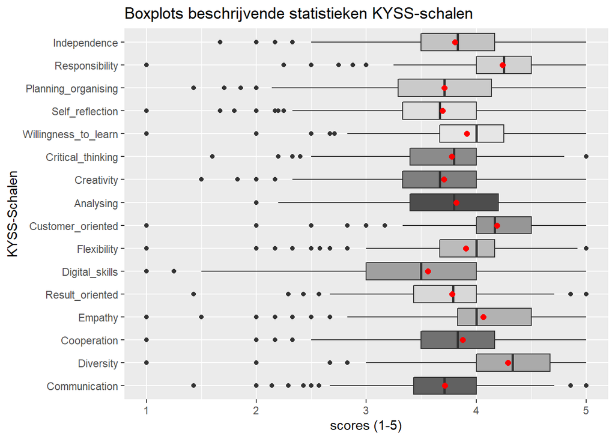

## 6.2 Correlations

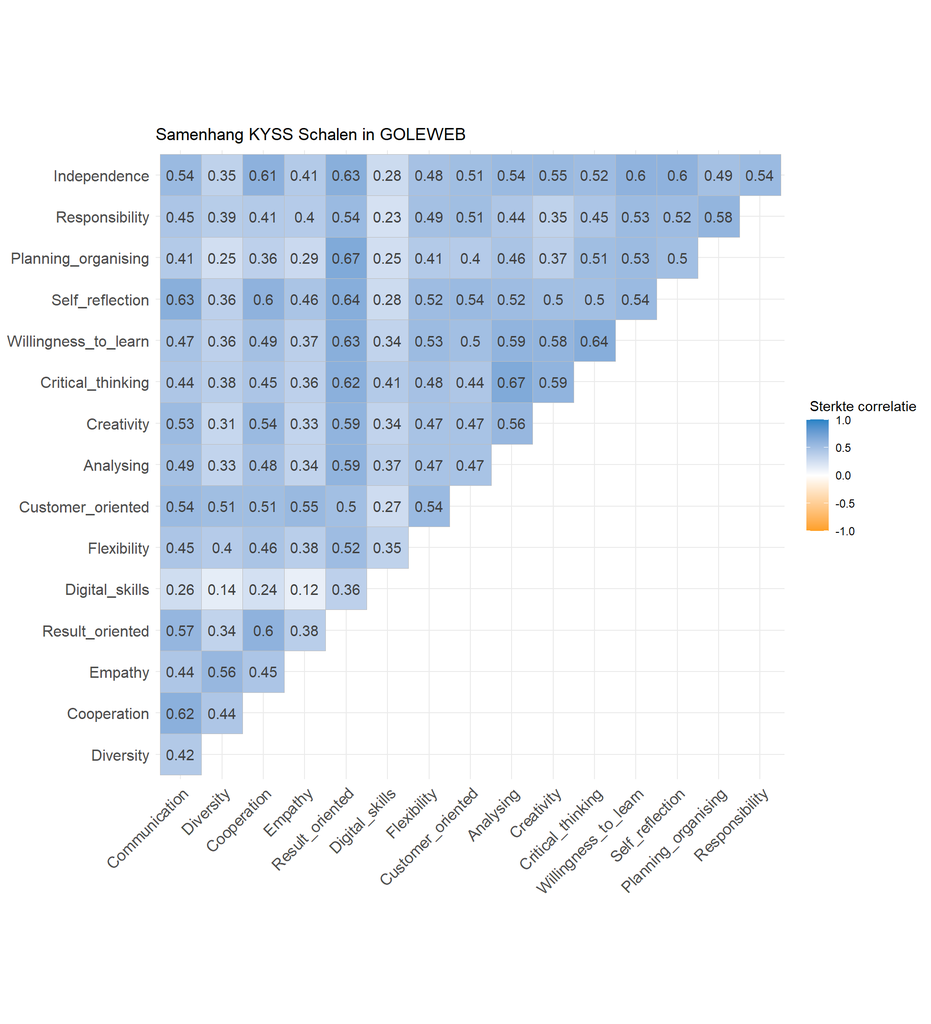

## 6.3 Predictive analyses using Gender as predictor

Table 6.1: ANOVA analyses with gender as predictor and scales in KYSS survey as dependent

| Characteristic | Female, N = 1,0111 | Male, N = 1,0161 | p-value2 |
| --- | --- | --- | --- |
| Creativity | 3.67 (0.57) | 3.74 (0.55) | 0.011 |
| Diversity | 4.37 (0.46) | 4.21 (0.52) | <0.001 |
| Flexibility | 3.90 (0.52) | 3.91 (0.50) | 0.6 |
| Planning_organising | 3.79 (0.57) | 3.63 (0.58) | <0.001 |
| Result_oriented | 3.78 (0.47) | 3.78 (0.49) | 0.8 |
| Cooperation | 3.88 (0.48) | 3.88 (0.51) | >0.9 |
| Communication | 3.73 (0.46) | 3.70 (0.49) | 0.2 |
| Digital_skills | 3.38 (0.67) | 3.73 (0.69) | <0.001 |
| Customer_oriented | 4.23 (0.47) | 4.15 (0.49) | <0.001 |
| Self_reflection | 3.73 (0.48) | 3.66 (0.55) | 0.004 |
| Independence | 3.85 (0.48) | 3.77 (0.48) | <0.001 |
| Responsibility | 4.30 (0.45) | 4.17 (0.49) | <0.001 |
| Willingness_to_learn | 3.94 (0.54) | 3.88 (0.56) | 0.020 |
| Analysing | 3.78 (0.52) | 3.85 (0.50) | 0.001 |
| Critical_thinking | 3.77 (0.51) | 3.78 (0.53) | 0.7 |
| Empathy | 4.16 (0.56) | 3.97 (0.54) | <0.001 |

1Mean (SD)  
2One-way ANOVA

Several significant results are observed. However, problems with measurement invariance prohibit interpreting significant results for *Digital skills*, *Customer Orientation* and *Willingness to Learn*. They also caution interpreting results for *Self-Reflection* and *Responsibility*. Based on the results of the measurement invariance analyses for *Diversity*, *Empathy*, *Analysing*, *Creativity*, *Planning and Organising* and *Independence*, means can be compared across gender for these scales. To help interpret the importance of these effects, effect sizes are provided for the latter scales in *Tables 6.2* to *6.9*.

Table 6.2: Eta squared measurement for effect size for the scale **Diversity**

| Parameter | Eta2 | CI | CI_low | CI_high |
| --- | --- | --- | --- | --- |
| factor(Gender) | 0.025 | 0.95 | 0.014 | 1 |

Table 6.3: Eta squared measurement for effect size for the scale **Empathy**

| Parameter | Eta2 | CI | CI_low | CI_high |
| --- | --- | --- | --- | --- |
| factor(Gender) | 0.027 | 0.95 | 0.017 | 1 |

Table 6.4: Eta squared measurement for effect size for the scale **Analysing**

| Parameter | Eta2 | CI | CI_low | CI_high |
| --- | --- | --- | --- | --- |
| factor(Gender) | 0.005 | 0.95 | 0.001 | 1 |

Table 6.5: Eta squared measurement for effect size for the scale **Creativity**

| Parameter | Eta2 | CI | CI_low | CI_high |
| --- | --- | --- | --- | --- |
| factor(Gender) | 0.004 | 0.95 | 0 | 1 |

Table 6.6: Eta squared measurement for effect size for the scale **Self Reflection**

| Parameter | Eta2 | CI | CI_low | CI_high |
| --- | --- | --- | --- | --- |
| factor(Gender) | 0.004 | 0.95 | 0.001 | 1 |

Table 6.7: Eta squared measurement for effect size for the scale **Planning and organising**

| Parameter | Eta2 | CI | CI_low | CI_high |
| --- | --- | --- | --- | --- |
| factor(Gender) | 0.018 | 0.95 | 0.01 | 1 |

Table 6.8: Eta squared measurement for effect size for the scale **Responsibility**

| Parameter | Eta2 | CI | CI_low | CI_high |
| --- | --- | --- | --- | --- |
| factor(Gender) | 0.018 | 0.95 | 0.01 | 1 |

Table 6.9: Eta squared measurement for effect size for the scale **Independence**

| Parameter | Eta2 | CI | CI_low | CI_high |
| --- | --- | --- | --- | --- |
| factor(Gender) | 0.007 | 0.95 | 0.002 | 1 |